# Review Pemodelan Regresi

Cintia Septemberini

August 30, 2023

## Regresi Linier

Pendekatan linier yang digunakan untuk membentuk model hubungan antara peubah respon dengan satu atau lebih peubah prediktor

## Regresi Linier Sederhana

Untuk model regresi linier dengan satu prediktor

$$y=\beta_0+\beta_1
X+\epsilon$$

Dimana:

- $X$ : peubah prediktor
- $y$ : peubah respon
- $\beta_0$ : intersep
- $\beta_1$ : slope
- $\epsilon$ : galat

## Regresi Linier Berganda

Dalam regresi linier sederhana, kita hanya mempertimbangkan satu peubah prediktor. Ketika kita memasukkan lebih dari satu peubah prediktor, maka kita memiliki model regresi linier berganda. Regresi linier berganda memungkinkan kita untuk menyelidiki pengaruh bersama beberapa prediktor terhadap peubah respon.

**NB: seperti halnya regresi linier sederhana kita memiliki satu peubah respon.**

Bentuk umum:

$$y=\beta_0+\beta_1 x_1+....+\beta_k x_k+\epsilon$$

Dimana:

- $y$ : peubah respon
- $x_1, x_2,….,x_k$ : peubah prediktor
- $\beta_0$ : intersep
- $\beta_1,….,\beta_k$ : parameter slope
- $\epsilon$ : galat

## Asumsi Klasik Model Regresi

Asumsi klasik bertujuan untuk memberikan kepastian bahwa persamaan regresi yang diperoleh memiliki ketepatan dalam pendugaan, tidak bias, dan konsisten. Asumsi-asumsi yang harus dipenuhi dalam analisis regresi antara lain:

- Linieritas

  Liniearitas merupakan sifat hubungan antar peubah yang bersifat linier. Linieritas dapat menunjukkan sejauh mana jika peubah respon diduga berbaring persis di garis lurus.
- Homokedastisitas

  Asumsi Homoskedastisitas yaitu asumsi yang menyatakan adanya kesamaan ragam dari galat untuk semua pengamatan pada suatu model regresi. Asumsi ini dapat ditulis sebagai berikut:

$$var(\epsilon_i)=\sigma^2, i=1,2,....,n$$

- Non-Autokorelasi

  Non-Autokorelasi berarti tidak ada pengaruh antara serangkaian pengamatan yang diurutkan menurut waktu atau tidak terjadi korelasi di antara galat randomnya.
- Normalitas

  Regresi linier mengasumsikan bahwa tiap $\epsilon_i$ didistribusikan secara normal dengan rata-rata nol dan ragam $\sigma^2$.

## Example: Cars

Sebagai ilustrasi, akan digunakan data `mtcars` yang tersedia pada package `dplyr`. Data diambil dari majalah Motor Trend US 1974 berisi mengenai konsumsi bahan bakar mobil dengan 10 aspek desain dan kinerjanya yang melibatkan 32 mobil (model 1973-1974).

```r
library(dplyr)
```

```r
data(mtcars)
names(mtcars)
```

[output not shown]

```r
head(mtcars)
```

|  | mpg | cyl | disp | hp | drat | wt | qsec | vs | am | gear | carb |
| --- | --- | --- | --- | --- | --- | --- | --- | --- | --- | --- | --- |
| Mazda RX4 | 21.0 | 6 | 160 | 110 | 3.90 | 2.620 | 16.46 | 0 | 1 | 4 | 4 |
| Mazda RX4 Wag | 21.0 | 6 | 160 | 110 | 3.90 | 2.875 | 17.02 | 0 | 1 | 4 | 4 |
| Datsun 710 | 22.8 | 4 | 108 | 93 | 3.85 | 2.320 | 18.61 | 1 | 1 | 4 | 1 |
| Hornet 4 Drive | 21.4 | 6 | 258 | 110 | 3.08 | 3.215 | 19.44 | 1 | 0 | 3 | 1 |
| Hornet Sportabout | 18.7 | 8 | 360 | 175 | 3.15 | 3.440 | 17.02 | 0 | 0 | 3 | 2 |
| Valiant | 18.1 | 6 | 225 | 105 | 2.76 | 3.460 | 20.22 | 1 | 0 | 3 | 1 |

Meskipun dataset ini memiliki 11 peubah yang berbeda, kita hanya akan menggunakan beberapa peubah tertentu. Peubah-peubah yang akan digunakan adalah:

- `disp` : displacement (measure in cubic inches)
- `hp` : gross horsepower
- `vs` : V-engine or straight engine (0 = berbentuk V, 1 = Lurus)
- `mpg` : miles per gallon

## Exploratory Data Analysis

### Observing the response variable

Pertama, lihat sebaran peubah respon yang digunakan yaitu `mpg`

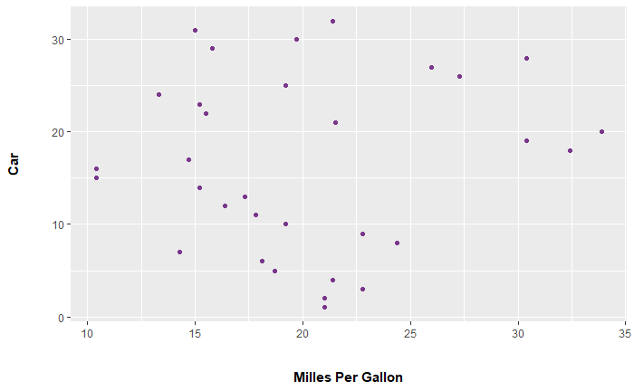

```r
library(ggplot2)
ggplot(mtcars,aes(x=mpg,y = seq_along(mpg))) +
geom_point(color = "mediumorchid4") +
xlab("\n\nMilles Per Gallon") + ylab("Car\n\n") +
theme(axis.title = element_text(face = "bold"))
```

### Displacement

Melihat hubungan antara `disp` dan peubah respon.

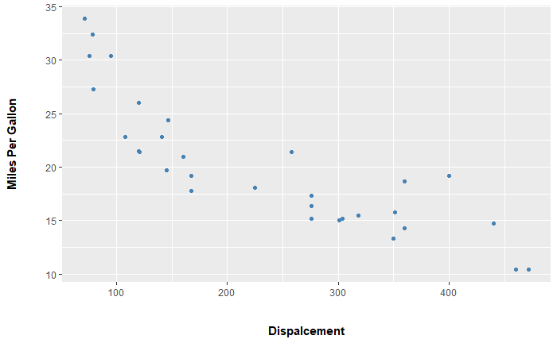

```r
ggplot(mtcars, aes(x=disp,y=mpg)) +
geom_point(color="steelblue") +
ylab("Miles Per Gallon\n\n") + xlab("\n\nDispalcement")+
theme(axis.title = element_text(face = "bold"))
```

Menghitung koefisien korelasi antara `disp` dan peubah respon.

```r
cor(mtcars$mpg,mtcars$disp)
```

```
[1] -0.8475514
```

Koefisien korelasi antara `disp` dan peubah respon yang diperoleh tinggi. Kedua peubah tersebut berhubungan kuat dengan arah negatif yang berarti ketika peningkatan satu peubah dikaitkan dengan penurunan peubah lainnya.

### Gross Horsepower

Melihat hubungan antara `hp` dan peubah respon.

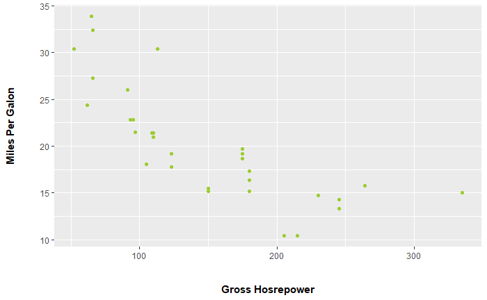

```r
ggplot(mtcars, aes(x=hp,y=mpg)) +
geom_point(color="olivedrab3")  +
ylab("Miles Per Galon\n\n") + xlab("\n\nGross Hosrepower")+
theme(axis.title = element_text(face = "bold"))
```

Menghitung koefisien korelasi antara `hp` dan peubah respon.

```r
cor(mtcars$mpg,mtcars$hp)
```

```
[1] -0.7761684
```

Koefisien korelasi antara `hp` dan peubah respon yang diperoleh tinggi. Kedua peubah tersebut berhubungan kuat dengan arah negatif yang berarti ketika peningkatan satu peubah dikaitkan dengan penurunan peubah lainnya.

### V-Engine or Straight Engine

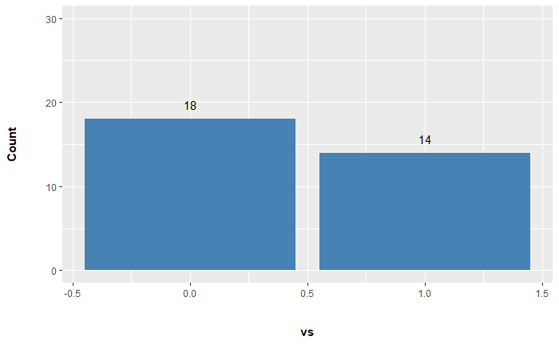

```r
ggplot(mtcars, aes(x=vs)) +
geom_bar(fill = "steelblue") +
geom_text(stat = "count", aes(label=..count..), vjust=-1) +
ylim(0,30)  +
ylab("Count\n\n") + xlab("\n\nvs")+
theme(axis.title = element_text(face = "bold"))
```

Terlihat bahwa meskipun proporsi mesin dengan V-engine lebih banyak, variasi antara V-engine dan straight engine kecil.

## Checking Multicolinearity

Salah satu hal pertama yang ingin kita lakukan sebelum membuat model apapun adalah memeriksa multikolinearitas antara peubah prediktor. Multikolinearitas terjadi ketika satu atau lebih prediktor dalam model regresi linier berganda berkorelasi tinggi. Multikolinearitas menjadi masalah karena akan meningkatkan standar error suatu model serta membuat estimasi parameter menjadi tidak konsisten.

### Correlation Matrices

```r
cor(mtcars[c(3,4)])
```

[output not shown]

Dianggap terjadi masalah multikolinieritas ketika nilai absolut korelasinya lebih besar dari 0,9. Sehinnga, dapat dikatakan bahwa tidak ada masalah multikolinieritas dalam model.

### Variance Inflation Factor

```r
model <- lm(mpg~disp+hp, data=mtcars)
library(car)
vif(model)
```

```
    disp       hp
2.670938 2.670938
```

Dianggap terjadi masalah multikolinieritas jika VIF>10, sehingga dapat dikatakan bahwa tidak ada masalah multikolinieritas dalam model.

## Building a Regression Model

Kita akan membuat pemodelan regresi linier berganda dengan menggunakan `mpg` sebagai peubah respon dan `disp`, `hp`, `vs` sebagai peubah independen.

```r
engine <-as.factor(mtcars$vs)
model_mpg <- lm(mpg ~ disp+hp+engine, data = mtcars)
summary(model_mpg)
```

[output not shown]

## Checking Model Assumptions

Pada poin ini, kita perlu memeriksa asumsi model untuk memastikan bahwa model tersebut memberikan hasil yang akurat.

### Linearity of the Data

Asumsi linearitas dapat diperiksa dengan memplotkan Residuals vs Fitted.

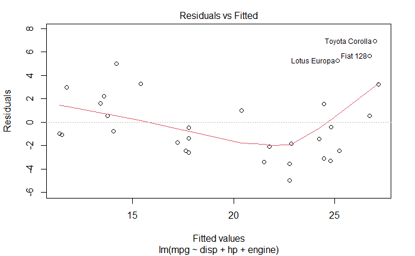

```r
plot(model_mpg, 1)
```

Seperti yang kita lihat, garis merah pada scatter plot yang menunjukkan hubungan dari keduanya membentuk kelengkungan. Idealnya garis merah tersebut harus lurus dan horizontal sempurna.

Untuk ini kita akan menggunakan versi lanjutan dari plot yang sama dengan menggunakan fungsi `residualPlots()` dari package `car`. Jika uji-t pada koefisien $\beta$ dari hasil fungsi `residualPlots()` signifikan maka terdapat hubungan non linier antara nilai fitted values dengan residualnya.

```
           Test stat Pr(>|Test stat|)
disp          2.7035        0.0117253 *
hp            2.5613        0.0163312 *
engine
Tukey test    3.3892        0.0007011 ***
---
Signif. codes:  0 ‘***’ 0.001 ‘**’ 0.01 ‘*’ 0.05 ‘.’ 0.1 ‘ ’ 1
```

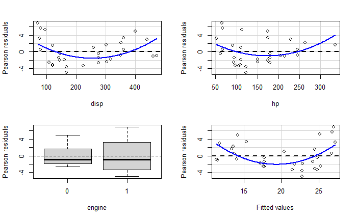

```r
residualPlots(model_mpg)
```

Hasil uji kelengkungan ternyata signifikan (nilai p <0,05), hal ini merupakan indikasi jelas adanya pelanggaran asumsi linearitas.

### Testing the Homoscedasticity Assumption

#### Scale-location plot

Asumsi ini dapat diperiksa dengan memeriksa scale-location plot.

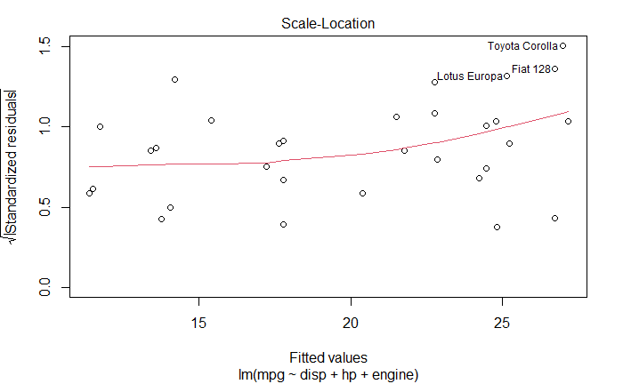

```r
plot(model_mpg, 3)
```

Idealnya garis yang diperoleh dalam plot harus cukup horizontal agar kondisi homokedastisitas terpenuhi. Meskipun tidak sempurna, garis merah pada plot tampak cukup horizontal untuk memenuhi kondisi tersebut.

#### Breusch-Pagan Test For Homoscedasticity

```r
library(lmtest)
bptest(model_mpg)
```

```
    studentized Breusch-Pagan test

data:  model_mpg
BP = 5.8019, df = 3, p-value = 0.1217
```

Karen $p>0,05$ maka terima $H_0$ yang berarti asumsi homokedastisitas terpenuhi.

### Testing the Independence (Autocorrelation) Assumption

#### Durbin Watson Test for Autocorrelation

Tes ini bisa sangat berguna ketika melakukan regresi dengan data deret waktu. Misalnya, pengujian ini dapat memberi tahu apakah galat pada titik waktu 1 berkorelasi dengan galat pada titik waktu 2 (seharusnya tidak demikian). Dengan kata lain, pengujian ini berguna untuk memverifikasi bahwa kita tidak melanggar asumsi independensi.

```r
durbinWatsonTest(model_mpg)
```

```
 lag Autocorrelation D-W Statistic p-value
   1       0.2871327      1.380061   0.058
 Alternative hypothesis: rho != 0
```

Karena $p>0,05$ maka terima $H_0$ yang berarti galatnya tidak berautokorelasi.

### Normality of Residuals

#### QQ Plot of Residuals

QQ-plot dapat digunakan untuk memeriksa asumsi normalitas secara visual. Idealnya, semua titik berada kira-kira di sepanjang garis, sehingga kita dapat mengasumsikan normalitas.

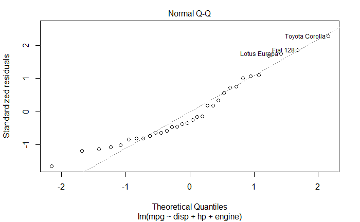

```r
plot(model_mpg, 2)
```

Distribusi galat tampak cukup normal, kecuali sedikit kemiringan pada bagian ekor yang dapat diabaikan. Oleh karena itu, kondisi normalitas terpenuhi.

#### Perform a Shapiro-Wilk Normality Test

```r
library(MASS)
sresid <- studres(model_mpg)
shapiro.test(sresid)
```

```
    Shapiro-Wilk normality test

data:  sresid
W = 0.9407, p-value = 0.07839
```

Karena $p>0,05$ maka terima $H_0$ yang berarti asumsi galat normalitas terpenuhi.